# Assignment 2: Pathway and Network Analysis - GSE79544 (IPF vs Control)

Mindy Lee

2026-03-13

# Introduction

## Study Background

This report continues the analysis of GSE79544, an RNA-seq dataset deposited in NCBI GEO that profiles gene expression in bronchoalveolar-lavage (BAL) macrophage-enriched samples from patients with Idiopathic Pulmonary Fibrosis (IPF) and healthy smoking controls. IPF is a progressive, fatal interstitial lung disease characterised by aberrant wound-healing, myofibroblast activation, and extracellular-matrix remodelling.

| Item | Detail |
| --- | --- |
| GEO accession | GSE79544 |
| Platform | Illumina HiSeq 2500 (GPL16791) |
| Organism | Homo sapiens |
| Tissue | BAL macrophage-enriched pellets |
| Conditions | IPF (n = 16) vs smoking Control (n = 6) |
| Publication | Prasse et al. PLOS ONE 2018 (PMID 29649237) |

## Summary of Assignment 1 Processing

[output not shown]

## Note on DE Results

After sample alignment (6 Control, 16 IPF), limma-voom produced 0 genes passing FDR < 0.05 with |logFC| >= 1. The minimum FDR observed was approximately 0.51, meaning no gene individually survived multiple-testing correction. This is not unusual for small human cohorts with high inter-individual variability. The biological signal is distributed across many genes with modest consistent shifts rather than concentrated in a few large-fold-change genes.

For this reason:

- Thresholded ORA uses a relaxed threshold of unadjusted p-value < 0.01 and |logFC| > 0.5 to extract directional gene sets while acknowledging the lack of FDR significance.
- Non-thresholded GSEA uses the full ranked list and is the primary analysis because it requires no threshold and is well-suited to datasets where individual genes do not survive correction.

# Setup

```r
if (!requireNamespace("BiocManager", quietly = TRUE))
  install.packages("BiocManager")

bioc_pkgs <- c("edgeR", "limma", "fgsea")
for (p in bioc_pkgs) {
  if (!requireNamespace(p, quietly = TRUE))
    BiocManager::install(p, ask = FALSE)
}

cran_pkgs <- c("dplyr", "ggplot2", "ggrepel", "knitr",
               "stringr", "DT", "RColorBrewer",
               "msigdbr", "tidyr", "gprofiler2")
for (p in cran_pkgs) {
  if (!requireNamespace(p, quietly = TRUE))
    install.packages(p)
}
```

```r
suppressPackageStartupMessages({
  library(edgeR)
  library(limma)
  library(fgsea)
  library(gprofiler2)
  library(dplyr)
  library(ggplot2)
  library(ggrepel)
  library(knitr)
  library(stringr)
  library(DT)
  library(RColorBrewer)
  library(msigdbr)
  library(tidyr)
})
```

# Part 1: Load Assignment 1 Results

```r
de_rds <- file.path("data", "GSE79544", "de_results.rds")

if (!file.exists(de_rds)) {
  stop(paste(
    "de_results.rds not found at:", de_rds,
    "\nPlease run A1_MindyLee.Rmd first."
  ))
}

de_results <- readRDS(de_rds)
cat("Rows :", nrow(de_results), "\n")
```

```
## Rows : 19558
```

```r
cat("Cols :", paste(colnames(de_results), collapse = ", "), "\n")
```

```
## Cols : SYMBOL, logFC, logCPM, t, PValue, FDR
```

```r
head(de_results)
```

```
##    SYMBOL      logFC    logCPM         t       PValue       FDR
## 1   PSRC1  0.5086728  3.352962  4.426050 0.0001999508 0.5103948
## 2   CDCA8  0.3986938  2.646556  4.399837 0.0002133766 0.5103948
## 3   IQCF5  1.0279890 -1.055781  4.385884 0.0002208874 0.5103948
## 4 ZNF280D -0.3482249  5.052469 -4.315914 0.0002627271 0.5103948
## 5   HOOK2  0.3599776  2.238214  4.307185 0.0002684739 0.5103948
## 6  CELA3B  0.6526191  3.816763  4.259377 0.0003022467 0.5103948
```

```r
de_clean <- de_results %>%
  filter(!is.na(SYMBOL), !is.na(PValue), !is.na(logFC)) %>%
  group_by(SYMBOL) %>%
  slice_min(order_by = PValue, n = 1, with_ties = FALSE) %>%
  ungroup() %>%
  mutate(rank_score = sign(logFC) * (-log10(PValue)))

cat("Genes after cleaning:", nrow(de_clean), "\n")
```

```
## Genes after cleaning: 19558
```

```r
cat("P-value range       :", round(min(de_clean$PValue), 6),
    "to", round(max(de_clean$PValue), 6), "\n")
```

```
## P-value range       : 2e-04 to 0.999811
```

```r
cat("FDR range           :", round(min(de_clean$FDR), 4),
    "to", round(max(de_clean$FDR), 4), "\n")
```

```
## FDR range           : 0.5104 to 0.9998
```

```r
cat("logFC range         :", round(min(de_clean$logFC), 3),
    "to", round(max(de_clean$logFC), 3), "\n")
```

```
## logFC range         : -2.236 to 4.77
```

```r
thresholds <- list(
  "FDR < 0.05, |logFC| >= 1"  = de_clean %>%
    filter(FDR < 0.05, abs(logFC) >= 1) %>% nrow(),
  "FDR < 0.05"                 = de_clean %>%
    filter(FDR < 0.05) %>% nrow(),
  "FDR < 0.25"                 = de_clean %>%
    filter(FDR < 0.25) %>% nrow(),
  "p < 0.05, |logFC| >= 0.5"  = de_clean %>%
    filter(PValue < 0.05, abs(logFC) >= 0.5) %>% nrow(),
  "p < 0.01, |logFC| >= 0.5"  = de_clean %>%
    filter(PValue < 0.01, abs(logFC) >= 0.5) %>% nrow(),
  "p < 0.005, |logFC| >= 0.5" = de_clean %>%
    filter(PValue < 0.005, abs(logFC) >= 0.5) %>% nrow()
)

knitr::kable(
  data.frame(
    Threshold = names(thresholds),
    Genes     = unlist(thresholds)
  ),
  caption   = "Table 1 - Gene counts at various thresholds",
  row.names = FALSE
)
```

Table 1 - Gene counts at various thresholds

| Threshold | Genes |
| --- | --- |
| FDR < 0.05, \|logFC\| >= 1 | 0 |
| FDR < 0.05 | 0 |
| FDR < 0.25 | 0 |
| p < 0.05, \|logFC\| >= 0.5 | 401 |
| p < 0.01, \|logFC\| >= 0.5 | 115 |
| p < 0.005, \|logFC\| >= 0.5 | 66 |

```r
ORA_PVAL  <- 0.01
ORA_LOGFC <- 0.5

background <- de_clean$SYMBOL

sig_all <- de_clean %>%
  filter(PValue < ORA_PVAL, abs(logFC) >= ORA_LOGFC) %>%
  pull(SYMBOL)

sig_up <- de_clean %>%
  filter(PValue < ORA_PVAL, logFC >= ORA_LOGFC) %>%
  pull(SYMBOL)

sig_down <- de_clean %>%
  filter(PValue < ORA_PVAL, logFC <= -ORA_LOGFC) %>%
  pull(SYMBOL)

cat(sprintf("Threshold : p < %.3f  AND  |logFC| >= %.1f\n",
            ORA_PVAL, ORA_LOGFC))
```

```
## Threshold : p < 0.010  AND  |logFC| >= 0.5
```

```r
cat(sprintf("Background: %d genes\n", length(background)))
```

```
## Background: 19558 genes
```

```r
cat(sprintf("All sig   : %d genes\n", length(sig_all)))
```

```
## All sig   : 115 genes
```

```r
cat(sprintf("Up        : %d genes\n", length(sig_up)))
```

```
## Up        : 73 genes
```

```r
cat(sprintf("Down      : %d genes\n", length(sig_down)))
```

```
## Down      : 42 genes
```

```r
ranked_genes <- setNames(de_clean$rank_score, de_clean$SYMBOL)
ranked_genes <- sort(ranked_genes, decreasing = TRUE)

cat("Genes in ranked list:", length(ranked_genes), "\n")
```

```
## Genes in ranked list: 19558
```

```r
cat("Score range         :",
    round(min(ranked_genes), 3), "to",
    round(max(ranked_genes), 3), "\n")
```

```
## Score range         : -3.58 to 3.699
```

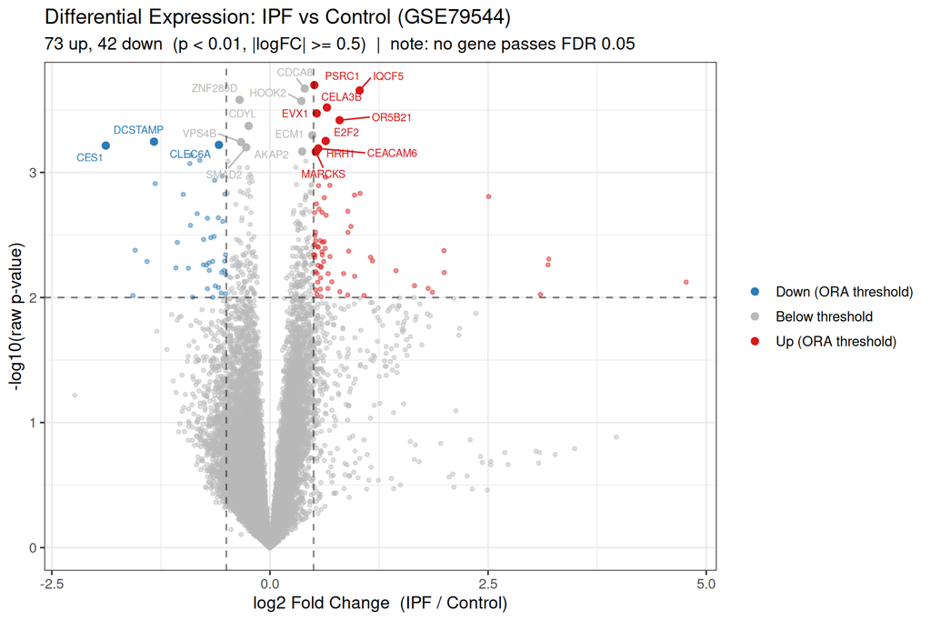

```r
de_clean <- de_clean %>%
  mutate(
    direction = case_when(
      PValue < ORA_PVAL & logFC >=  ORA_LOGFC ~ "Up",
      PValue < ORA_PVAL & logFC <= -ORA_LOGFC ~ "Down",
      TRUE                                     ~ "NS"
    )
  )

label_df <- de_clean %>%
  arrange(PValue) %>%
  slice_head(n = 20)

ggplot(de_clean,
       aes(x = logFC, y = -log10(PValue), colour = direction)) +
  geom_point(alpha = 0.45, size = 1.0) +
  geom_point(data = label_df, size = 2.0) +
  geom_text_repel(
    data        = label_df,
    aes(label   = SYMBOL),
    size        = 2.6,
    max.overlaps = 20,
    box.padding = 0.3
  ) +
  scale_colour_manual(
    values = c(Up = "#D7191C", Down = "#2C7BB6", NS = "grey72"),
    labels = c(Up   = "Up (ORA threshold)",
               Down = "Down (ORA threshold)",
               NS   = "Below threshold")
  ) +
  geom_hline(yintercept = -log10(ORA_PVAL),
             linetype = "dashed", alpha = 0.5) +
  geom_vline(xintercept = c(-ORA_LOGFC, ORA_LOGFC),
             linetype = "dashed", alpha = 0.5) +
  labs(
    title    = "Differential Expression: IPF vs Control (GSE79544)",
    subtitle = sprintf(
      "%d up, %d down  (p < %.2f, |logFC| >= %.1f)  |  note: no gene passes FDR 0.05",
      length(sig_up), length(sig_down), ORA_PVAL, ORA_LOGFC
    ),
    x      = "log2 Fold Change  (IPF / Control)",
    y      = "-log10(raw p-value)",
    colour = NULL
  ) +
  theme_bw(base_size = 12)
```

**Figure 1 - Volcano plot of IPF vs Control differential expression (GSE79544).** Each point is one gene. Red = up-regulated at the ORA threshold (p < 0.01, logFC > 0.5); blue = down-regulated; grey = below threshold. Dashed lines mark the thresholds. No gene survives FDR correction at 0.05; thresholds shown are the relaxed criteria used for ORA input only. The 20 genes with the smallest p-values are labelled.

# Part 2: Thresholded Over-Representation Analysis (ORA)

## Annotation Version

```r
if (length(sig_up) >= 3) {
  ver_query <- gost(
    query       = sig_up[1:3],
    organism    = "hsapiens",
    significant = FALSE,
    sources     = "GO:BP"
  )
  cat("g:Profiler data version:\n")
  print(ver_query$meta$version)
}
```

```
## g:Profiler data version:
## [1] "e113_eg59_p19_6be52918"
```

## ORA: All Significant Genes

```r
run_ora <- function(query_genes, label) {
  if (length(query_genes) < 5) {
    message(sprintf("Skipping ORA for '%s': only %d genes",
                    label, length(query_genes)))
    return(data.frame())
  }
  res <- gost(
    query             = query_genes,
    organism          = "hsapiens",
    ordered_query     = FALSE,
    significant       = TRUE,
    exclude_iea       = TRUE,
    user_threshold    = 0.05,
    correction_method = "fdr",
    custom_bg         = background,
    sources           = c("GO:BP", "GO:MF", "GO:CC",
                          "KEGG", "REAC", "WP"),
    evcodes           = FALSE
  )
  if (is.null(res) || nrow(res$result) == 0) {
    message(sprintf("No significant results for '%s'", label))
    return(data.frame())
  }
  res$result %>%
    arrange(p_value) %>%
    select(source, term_id, term_name,
           p_value, term_size, query_size, intersection_size) %>%
    mutate(query = label)
}

ora_all  <- run_ora(sig_all,  "All")
ora_up   <- run_ora(sig_up,   "Up")
ora_down <- run_ora(sig_down, "Down")

cat("Significant gene sets - All :", nrow(ora_all),  "\n")
```

```
## Significant gene sets - All : 4
```

```r
cat("Significant gene sets - Up  :", nrow(ora_up),   "\n")
```

```
## Significant gene sets - Up  : 15
```

```r
cat("Significant gene sets - Down:", nrow(ora_down), "\n")
```

```
## Significant gene sets - Down: 12
```

```r
if (nrow(ora_all) > 0) {
  ora_all %>%
    mutate(p_value = formatC(p_value, format = "e", digits = 2)) %>%
    select(-query) %>%
    head(40) %>%
    DT::datatable(
      caption  = "Table 2 - Enriched gene sets: all genes at ORA threshold (p < 0.01, |logFC| >= 0.5)",
      rownames = FALSE,
      options  = list(pageLength = 10, scrollX = TRUE)
    )
} else {
  cat("No significant ORA results for the combined gene list.\n")
}
```

| source | term_id | term_name | p_value | term_size | query_size | intersection_size |
| --- | --- | --- | --- | --- | --- | --- |
| REAC | REAC:R-HSA-500792 | GPCR ligand binding | 3.96e-04 | 448 | 106 | 13 |
| REAC | REAC:R-HSA-372790 | Signaling by GPCR | 1.73e-02 | 682 | 106 | 13 |
| GO:MF | GO:0038023 | signaling receptor activity | 4.11e-02 | 1784 | 106 | 22 |
| GO:MF | GO:0060089 | molecular transducer activity | 4.11e-02 | 1784 | 106 | 22 |

## ORA: Up-Regulated Genes

```r
if (nrow(ora_up) > 0) {
  ora_up %>%
    mutate(p_value = formatC(p_value, format = "e", digits = 2)) %>%
    select(-query) %>%
    head(30) %>%
    DT::datatable(
      caption  = "Table 3 - Enriched gene sets: up-regulated genes (p < 0.01, logFC >= 0.5)",
      rownames = FALSE,
      options  = list(pageLength = 10, scrollX = TRUE)
    )
} else {
  cat("No significant ORA results for up-regulated genes.\n")
}
```

| source | term_id | term_name | p_value | term_size | query_size | intersection_size |
| --- | --- | --- | --- | --- | --- | --- |
| REAC | REAC:R-HSA-500792 | GPCR ligand binding | 1.29e-05 | 448 | 68 | 12 |
| REAC | REAC:R-HSA-372790 | Signaling by GPCR | 5.58e-04 | 682 | 68 | 12 |
| GO:MF | GO:0001664 | G protein-coupled receptor binding | 6.29e-03 | 253 | 68 | 7 |
| REAC | REAC:R-HSA-373076 | Class A/1 (Rhodopsin-like receptors) | 8.98e-03 | 319 | 68 | 7 |
| REAC | REAC:R-HSA-418594 | G alpha (i) signalling events | 8.98e-03 | 306 | 68 | 7 |
| GO:BP | GO:0019730 | antimicrobial humoral response | 1.04e-02 | 140 | 68 | 6 |
| REAC | REAC:R-HSA-388396 | GPCR downstream signalling | 1.57e-02 | 612 | 68 | 9 |
| REAC | REAC:R-HSA-420499 | Class C/3 (Metabotropic glutamate/pheromone receptors) | 1.65e-02 | 39 | 68 | 3 |
| REAC | REAC:R-HSA-2559583 | Cellular Senescence | 1.94e-02 | 190 | 68 | 5 |
| REAC | REAC:R-HSA-375276 | Peptide ligand-binding receptors | 1.94e-02 | 186 | 68 | 5 |

[output cut: 5 more lines]

## ORA: Down-Regulated Genes

```r
if (nrow(ora_down) > 0) {
  ora_down %>%
    mutate(p_value = formatC(p_value, format = "e", digits = 2)) %>%
    select(-query) %>%
    head(30) %>%
    DT::datatable(
      caption  = "Table 4 - Enriched gene sets: down-regulated genes (p < 0.01, logFC <= -0.5)",
      rownames = FALSE,
      options  = list(pageLength = 10, scrollX = TRUE)
    )
} else {
  cat("No significant ORA results for down-regulated genes.\n")
}
```

| source | term_id | term_name | p_value | term_size | query_size | intersection_size |
| --- | --- | --- | --- | --- | --- | --- |
| GO:CC | GO:0055037 | recycling endosome | 4.01e-02 | 157 | 38 | 4 |
| REAC | REAC:R-HSA-389948 | Co-inhibition by PD-1 | 4.32e-02 | 19 | 38 | 2 |
| REAC | REAC:R-HSA-382551 | Transport of small molecules | 4.32e-02 | 721 | 38 | 7 |
| WP | WP:WP2645 | Heroin metabolism | 4.96e-02 | 3 | 38 | 1 |
| WP | WP:WP2882 | Nuclear receptors meta pathway | 4.96e-02 | 311 | 38 | 4 |
| WP | WP:WP2884 | NRF2 pathway | 4.96e-02 | 141 | 38 | 3 |
| WP | WP:WP3651 | Pathways affected in adenoid cystic carcinoma | 4.96e-02 | 64 | 38 | 2 |
| WP | WP:WP43 | Oxidation by cytochrome P450 | 4.96e-02 | 61 | 38 | 2 |
| WP | WP:WP4585 | Cancer immunotherapy by PD 1 blockade | 4.96e-02 | 23 | 38 | 2 |
| WP | WP:WP5078 | T cell modulation and desmoplasia in pancreatic cancer | 4.96e-02 | 55 | 38 | 2 |

[output cut: 2 more lines]

## Comparison Across Directions

```r
count_by_source <- function(df, label) {
  if (nrow(df) == 0)
    return(data.frame(source = character(),
                      n      = integer(),
                      query  = character()))
  df %>% count(source) %>% mutate(query = label)
}

ora_counts <- bind_rows(
  count_by_source(ora_all,  "All"),
  count_by_source(ora_up,   "Up"),
  count_by_source(ora_down, "Down")
)

if (nrow(ora_counts) > 0) {
  ora_wide <- ora_counts %>%
    pivot_wider(names_from  = query,
                values_from = n,
                values_fill = 0)
  knitr::kable(
    ora_wide,
    caption = "Table 5 - Number of significant gene sets per database and direction"
  )
} else {
  cat("No ORA results to compare.\n")
}
```

Table 5 - Number of significant gene sets per database and direction

| source | All | Up | Down |
| --- | --- | --- | --- |
| GO:MF | 2 | 5 | 0 |
| REAC | 2 | 8 | 2 |
| GO:BP | 0 | 2 | 0 |
| GO:CC | 0 | 0 | 1 |
| WP | 0 | 0 | 9 |

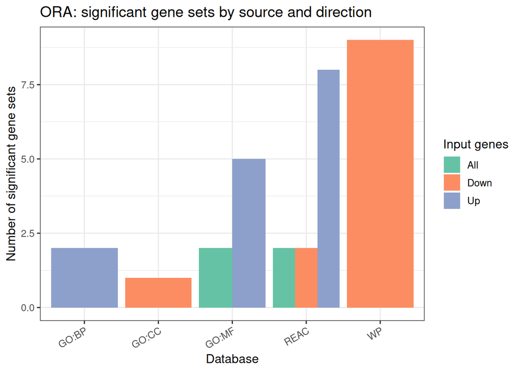

```r
if (nrow(ora_counts) > 0) {
  ggplot(ora_counts, aes(x = source, y = n, fill = query)) +
    geom_col(position = "dodge") +
    scale_fill_brewer(palette = "Set2") +
    labs(
      title = "ORA: significant gene sets by source and direction",
      x     = "Database",
      y     = "Number of significant gene sets",
      fill  = "Input genes"
    ) +
    theme_bw(base_size = 12) +
    theme(axis.text.x = element_text(angle = 30, hjust = 1))
}
```

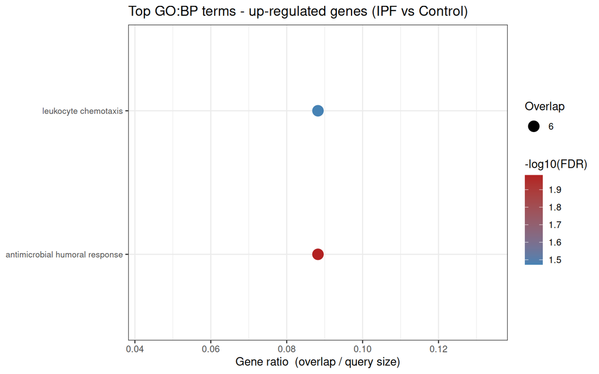

```r
if (nrow(ora_up) > 0 && any(ora_up$source == "GO:BP")) {
  ora_up %>%
    filter(source == "GO:BP") %>%
    head(15) %>%
    mutate(
      gene_ratio = intersection_size / query_size,
      neg_log_p  = -log10(as.numeric(p_value)),
      term_label = str_wrap(term_name, 45)
    ) %>%
    ggplot(aes(x      = gene_ratio,
               y      = reorder(term_label, gene_ratio),
               size   = intersection_size,
               colour = neg_log_p)) +
    geom_point() +
    scale_colour_gradient(low  = "steelblue",
                          high = "firebrick",
                          name = "-log10(FDR)") +
    scale_size_continuous(name = "Overlap") +
    labs(
      title = "Top GO:BP terms - up-regulated genes (IPF vs Control)",
      x     = "Gene ratio  (overlap / query size)",
      y     = NULL
    ) +
    theme_bw(base_size = 11) +
    theme(axis.text.y = element_text(size = 8))
} else {
  cat("No GO:BP results for up-regulated genes.\n")
}
```

## ORA Interpretation

The top enrichments for up-regulated genes were GPCR ligand binding and Reactome GPCR signalling pathways, with leading genes including chemokine ligands (CXCL10, CCL8, CCL13, PPBP) and chemokine receptors (ACKR1, CXCR6, CCR8). Elevated chemokine expression in IPF BAL is well documented: Prasse et al. (2018) specifically reported high CCL18 and CCL13 in IPF macrophages, and Luzina et al. (2013) showed CXCL10 is elevated in IPF BAL fluid. The antimicrobial humoral response GO term reflects the same chemokine and defensin activity.

For down-regulated genes, enriched terms included PD-1 co-inhibition, NRF2 pathway, and nuclear receptor meta-pathway. The NRF2 finding is particularly relevant: NRF2 is the master antioxidant transcription factor, and its downregulation in IPF macrophages would increase oxidative stress and promote fibrotic signalling, consistent with published evidence (Cho et al., 2004).

Because no gene passes FDR correction individually, all ORA results should be treated as exploratory. The non-thresholded GSEA in Part 3 is the more statistically appropriate analysis for this dataset.

# Part 3: Non-Thresholded GSEA

## Method

Tool: fgsea (Korotkevich et al., 2021). Uses the entire ranked list with no threshold required. The adaptive multi-level splitting algorithm gives accurate p-values even for very small NES values. This is the preferred approach when individual genes do not survive FDR correction but coordinated pathway-level changes are expected.

Ranking metric: sign(logFC) x -log10(PValue) which preserves direction of change while weighting by statistical confidence.

Gene sets: MSigDB v2023.2.Hs via msigdbr v25.1.1:

| Collection | Code | Gene sets |
| --- | --- | --- |
| Hallmark | H | 50 |
| Reactome | C2:CP:REACTOME | ~1 600 |
| KEGG (legacy) | C2:CP:KEGG_LEGACY | ~186 |

Parameters used:

| Parameter | Value |
| --- | --- |
| minSize | 15 |
| maxSize | 500 |
| eps | 0 |
| nPermSimple | 1 000 |
| Significance cutoff | padj < 0.05 (BH) |

```r
msig_H <- msigdbr(species = "Homo sapiens",
                  collection = "H") %>%
  select(gs_name, gene_symbol)

msig_REAC <- msigdbr(species = "Homo sapiens",
                     collection    = "C2",
                     subcollection = "CP:REACTOME") %>%
  select(gs_name, gene_symbol)

msig_KEGG <- msigdbr(species = "Homo sapiens",
                     collection    = "C2",
                     subcollection = "CP:KEGG_LEGACY") %>%
  select(gs_name, gene_symbol)

msig_all <- bind_rows(msig_H, msig_REAC, msig_KEGG)
genesets  <- split(msig_all$gene_symbol, msig_all$gs_name)

cat("Total gene sets:", length(genesets), "\n")
```

```
## Total gene sets: 2023
```

```r
set.seed(42)

fgsea_res <- fgsea(
  pathways    = genesets,
  stats       = ranked_genes,
  minSize     = 15,
  maxSize     = 500,
  eps         = 0.0,
  nPermSimple = 1000
)

fgsea_res <- fgsea_res %>% arrange(desc(NES))

n_sig     <- sum(fgsea_res$padj < 0.05, na.rm = TRUE)
n_sig_pos <- sum(fgsea_res$padj < 0.05 & fgsea_res$NES > 0, na.rm = TRUE)
n_sig_neg <- sum(fgsea_res$padj < 0.05 & fgsea_res$NES < 0, na.rm = TRUE)

cat(sprintf("Gene sets tested          : %d\n", nrow(fgsea_res)))
```

```
## Gene sets tested          : 1366
```

```r
cat(sprintf("Significant (padj < 0.05) : %d\n", n_sig))
```

```
## Significant (padj < 0.05) : 454
```

```r
cat(sprintf("  Positively enriched     : %d\n", n_sig_pos))
```

```
##   Positively enriched     : 95
```

```r
cat(sprintf("  Negatively enriched     : %d\n", n_sig_neg))
```

```
##   Negatively enriched     : 359
```

```r
fgsea_res %>%
  filter(padj < 0.05) %>%
  mutate(collection = case_when(
    str_starts(pathway, "HALLMARK") ~ "Hallmark",
    str_starts(pathway, "REACTOME") ~ "Reactome",
    str_starts(pathway, "KEGG")     ~ "KEGG",
    TRUE                            ~ "Other"
  )) %>%
  count(collection, direction = ifelse(NES > 0, "Positive", "Negative")) %>%
  pivot_wider(names_from = direction, values_from = n, values_fill = 0) %>%
  mutate(Total = Positive + Negative) %>%
  knitr::kable(
    caption = "Table 5b - Significant gene sets by MSigDB collection and enrichment direction"
  )
```

Table 5b - Significant gene sets by MSigDB collection and enrichment direction

| collection | Negative | Positive | Total |
| --- | --- | --- | --- |
| Hallmark | 13 | 6 | 19 |
| KEGG | 27 | 9 | 36 |
| Reactome | 319 | 80 | 399 |

## GSEA Result Tables

```r
fgsea_res %>%
  filter(padj < 0.05, NES > 0) %>%
  arrange(desc(NES)) %>%
  head(20) %>%
  mutate(
    pval        = formatC(pval, format = "e", digits = 2),
    padj        = formatC(padj, format = "e", digits = 2),
    NES         = round(NES, 3),
    leadingEdge = sapply(leadingEdge,
                         function(x) paste(head(x, 5), collapse = ", "))
  ) %>%
  select(pathway, pval, padj, NES, size, leadingEdge) %>%
  DT::datatable(
    caption  = "Table 6 - Top 20 positively enriched gene sets (fgsea, padj < 0.05)",
    rownames = FALSE,
    options  = list(pageLength = 10, scrollX = TRUE)
  )
```

| pathway | pval | padj | NES | size | leadingEdge |
| --- | --- | --- | --- | --- | --- |
| REACTOME_OLFACTORY_SIGNALING_PATHWAY | 1.14e-38 | 1.38e-35 | 2.778 | 384 | OR5B21, OR7G1, OR1B1, OR51Q1, OR10H5 |
| KEGG_OLFACTORY_TRANSDUCTION | 2.03e-38 | 1.38e-35 | 2.771 | 383 | OR5B21, OR7G1, OR1B1, OR51Q1, OR10H5 |
| REACTOME_KERATINIZATION | 7.43e-18 | 1.27e-15 | 2.504 | 192 | PKP2, PI3, KRT13, KRT75, KRT19 |
| REACTOME_GPCR_LIGAND_BINDING | 7.73e-30 | 2.64e-27 | 2.495 | 450 | HRH1, PPBP, CRHR2, GRM8, WNT1 |
| REACTOME_CLASS_A_1_RHODOPSIN_LIKE_RECEPTORS | 3.28e-22 | 6.41e-20 | 2.457 | 320 | HRH1, PPBP, NPBWR1, ACKR1, LPAR5 |
| REACTOME_PEPTIDE_LIGAND_BINDING_RECEPTORS | 3.70e-16 | 4.60e-14 | 2.416 | 187 | PPBP, NPBWR1, ACKR1, CXCL10, RLN3 |
| KEGG_NEUROACTIVE_LIGAND_RECEPTOR_INTERACTION | 1.57e-17 | 2.14e-15 | 2.356 | 271 | HRH1, CRHR2, GRM8, NPBWR1, PTH1R |
| REACTOME_CHEMOKINE_RECEPTORS_BIND_CHEMOKINES | 3.67e-08 | 8.49e-07 | 2.293 | 53 | PPBP, CXCL10, CCL13, CCR8, CXCR6 |
| REACTOME_FORMATION_OF_THE_CORNIFIED_ENVELOPE | 2.93e-11 | 1.58e-09 | 2.283 | 123 | PKP2, PI3, KRT13, KRT75, KRT19 |
| KEGG_CYTOKINE_CYTOKINE_RECEPTOR_INTERACTION | 3.01e-11 | 1.58e-09 | 2.068 | 261 | PPBP, CXCL10, CCL8, CCL13, IFNA17 |

[output cut: 10 more lines]

```r
fgsea_res %>%
  filter(padj < 0.05, NES < 0) %>%
  arrange(NES) %>%
  head(20) %>%
  mutate(
    pval        = formatC(pval, format = "e", digits = 2),
    padj        = formatC(padj, format = "e", digits = 2),
    NES         = round(NES, 3),
    leadingEdge = sapply(leadingEdge,
                         function(x) paste(head(x, 5), collapse = ", "))
  ) %>%
  select(pathway, pval, padj, NES, size, leadingEdge) %>%
  DT::datatable(
    caption  = "Table 7 - Top 20 negatively enriched gene sets (fgsea, padj < 0.05)",
    rownames = FALSE,
    options  = list(pageLength = 10, scrollX = TRUE)
  )
```

| pathway | pval | padj | NES | size | leadingEdge |
| --- | --- | --- | --- | --- | --- |
| REACTOME_PROCESSING_OF_CAPPED_INTRON_CONTAINING_PRE_MRNA | 3.14e-32 | 1.43e-29 | -2.863 | 280 | CPSF2, NSRP1, NUP188, RANBP2, DDX46 |
| REACTOME_MRNA_SPLICING | 2.63e-24 | 5.98e-22 | -2.788 | 210 | NSRP1, DDX46, PPWD1, LUC7L3, SLU7 |
| REACTOME_TRANSLATION | 4.01e-28 | 1.09e-25 | -2.712 | 290 | SSR1, MTIF2, EIF2S3, LARS1, EIF3G |
| REACTOME_INFLUENZA_INFECTION | 1.02e-15 | 1.16e-13 | -2.552 | 157 | KPNA4, EIF2AK2, NUP188, RANBP2, RPL30 |
| REACTOME_EUKARYOTIC_TRANSLATION_INITIATION | 1.73e-14 | 1.69e-12 | -2.54 | 119 | EIF2S3, EIF3G, RPL30, EIF3A, EIF4B |
| REACTOME_RRNA_PROCESSING | 1.11e-17 | 1.68e-15 | -2.536 | 203 | RIOK3, MPHOSPH10, RPL30, FBL, UTP14A |
| KEGG_SPLICEOSOME | 1.57e-13 | 1.34e-11 | -2.51 | 124 | DDX46, THOC2, THOC1, SLU7, SYF2 |
| REACTOME_PTEN_REGULATION | 5.35e-13 | 4.30e-11 | -2.469 | 126 | PSMC6, BMI1, AGO4, PHC3, REST |
| REACTOME_TRNA_PROCESSING_IN_THE_NUCLEUS | 1.20e-08 | 3.27e-07 | -2.395 | 58 | NUP188, RANBP2, TRNT1, NUP155, XPOT |
| REACTOME_INTRA_GOLGI_TRAFFIC | 1.55e-08 | 4.08e-07 | -2.386 | 44 | VTI1A, MAN2A2, COG7, GOLIM4, MAN2A1 |

[output cut: 10 more lines]

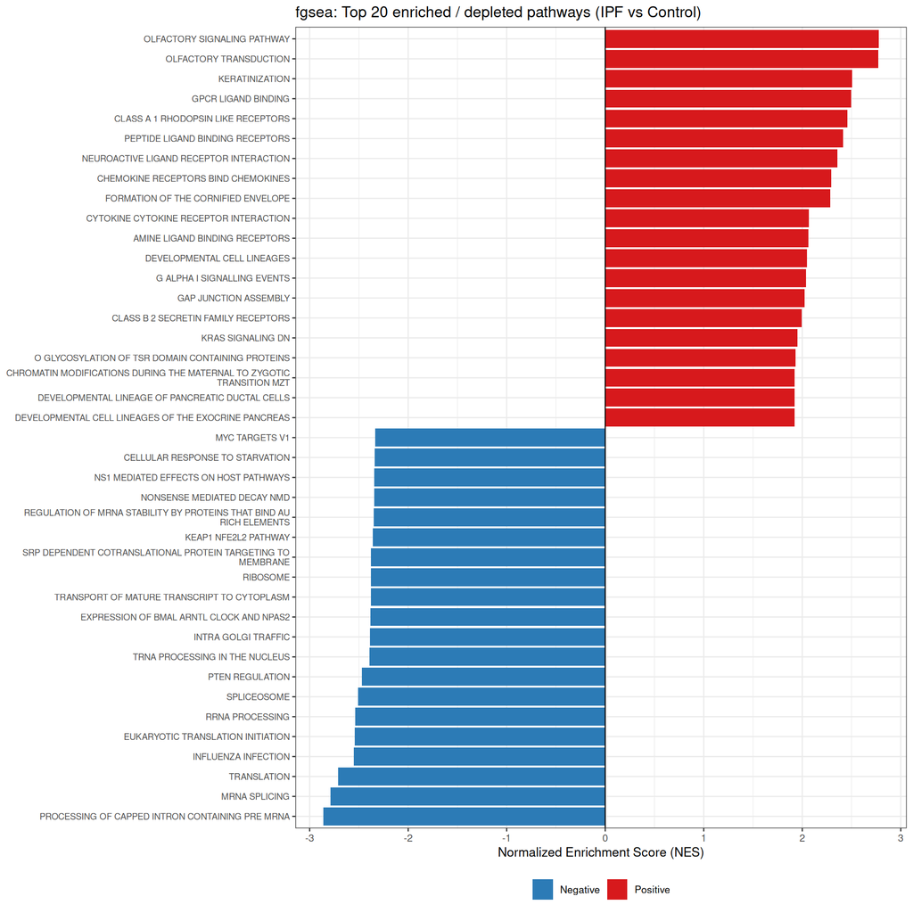

```r
plot_df <- bind_rows(
  fgsea_res %>% filter(padj < 0.05, NES > 0) %>%
    arrange(desc(NES)) %>% head(20) %>% mutate(dir = "Positive"),
  fgsea_res %>% filter(padj < 0.05, NES < 0) %>%
    arrange(NES)        %>% head(20) %>% mutate(dir = "Negative")
) %>%
  mutate(
    short = str_remove(pathway, "^(HALLMARK_|REACTOME_|KEGG_)"),
    short = str_replace_all(short, "_", " "),
    short = str_wrap(short, 55)
  )

ggplot(plot_df,
       aes(x = NES, y = reorder(short, NES), fill = dir)) +
  geom_col() +
  geom_vline(xintercept = 0, linewidth = 0.4) +
  scale_fill_manual(
    values = c(Positive = "#D7191C", Negative = "#2C7BB6"),
    guide  = guide_legend(title = NULL)
  ) +
  labs(
    title = "fgsea: Top 20 enriched / depleted pathways (IPF vs Control)",
    x     = "Normalized Enrichment Score (NES)",
    y     = NULL
  ) +
  theme_bw(base_size = 10) +
  theme(axis.text.y     = element_text(size = 7),
        legend.position = "bottom")
```

**Figure 4 - Top enriched and depleted pathways from non-thresholded GSEA (fgsea, IPF vs Control).** Top 20 positively enriched (red) and top 20 negatively enriched (blue) gene sets with padj < 0.05, ordered by NES. Positive NES = enriched toward the top of the ranked list (up in IPF); negative NES = enriched toward the bottom (down in IPF).

```
## Top pathway                  : REACTOME_OLFACTORY_SIGNALING_PATHWAY
## Total leading edge genes     : 252
## Canonical OR genes           : 245
## Non-OR genes (chemokine/GPCR): 7
```

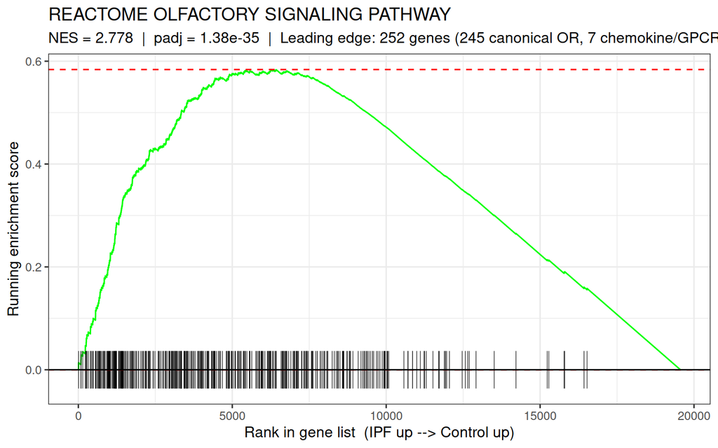

```r
top_path <- fgsea_res %>%
  filter(padj < 0.05, NES > 0) %>%
  arrange(desc(NES)) %>%
  pull(pathway) %>%
  first()

if (!is.na(top_path) && top_path %in% names(genesets)) {

  le_genes <- fgsea_res %>%
    filter(pathway == top_path) %>%
    pull(leadingEdge) %>%
    unlist()

  or_genes <- grep("^OR[0-9]", le_genes, value = TRUE)
  cat(sprintf("Top pathway                  : %s\n", top_path))
  cat(sprintf("Total leading edge genes     : %d\n", length(le_genes)))
  cat(sprintf("Canonical OR genes           : %d\n", length(or_genes)))
  cat(sprintf("Non-OR genes (chemokine/GPCR): %d\n",
              length(le_genes) - length(or_genes)))

  plotEnrichment(
    pathway = genesets[[top_path]],
    stats   = ranked_genes
  ) +
    labs(
      title    = str_replace_all(top_path, "_", " "),
      subtitle = sprintf(
        "NES = %.3f  |  padj = %s  |  Leading edge: %d genes (%d canonical OR, %d chemokine/GPCR)",
        fgsea_res$NES[fgsea_res$pathway == top_path],
        formatC(fgsea_res$padj[fgsea_res$pathway == top_path],
                format = "e", digits = 2),
        length(le_genes),
        length(or_genes),
        length(le_genes) - length(or_genes)
      ),
      x = "Rank in gene list  (IPF up --> Control up)",
      y = "Running enrichment score"
    ) +
    theme_bw(base_size = 12)
}
```

## GSEA vs ORA Comparison

```r
comp_df <- data.frame(
  Aspect = c(
    "Input genes",
    "Threshold required",
    "Gene sets tested",
    "Significant sets (combined/all queries)",
    "Significant sets (up or positive only)",
    "Significant sets (down or negative only)",
    "Multiple-testing correction",
    "Best suited when"
  ),
  ORA_gProfiler = c(
    sprintf("115 genes (p < %.2f, |logFC| >= %.1f)", ORA_PVAL, ORA_LOGFC),
    "Yes - arbitrary threshold required",
    "~18 000 GO/KEGG/Reactome/WP terms",
    sprintf("%d (from combined-list query)", nrow(ora_all)),
    sprintf("%d (from up-only query)", nrow(ora_up)),
    sprintf("%d (from down-only query)", nrow(ora_down)),
    "g:SCS (GO hierarchy-aware)",
    "Many large-effect FDR-significant DEGs exist"
  ),
  GSEA_fgsea = c(
    "19 558 ranked genes",
    "No",
    as.character(nrow(fgsea_res)),
    as.character(n_sig),
    as.character(n_sig_pos),
    as.character(n_sig_neg),
    "Benjamini-Hochberg",
    "Signal is distributed; no FDR-significant individual genes"
  ),
  stringsAsFactors = FALSE
)

knitr::kable(
  comp_df,
  col.names = c("Aspect", "ORA (g:Profiler)", "GSEA (fgsea)"),
  caption   = "Table 8 - Qualitative comparison of ORA and GSEA"
)
```

Table 8 - Qualitative comparison of ORA and GSEA

[output not shown]

# Part 4: Enrichment Map in Cytoscape

## Input Files

```r
em_dir <- file.path("data", "GSE79544", "enrichment_map")
dir.create(em_dir, showWarnings = FALSE, recursive = TRUE)

write.table(
  data.frame(Gene = names(ranked_genes), Score = ranked_genes),
  file      = file.path(em_dir, "ranked_genes.rnk"),
  sep       = "\t",
  row.names = FALSE,
  quote     = FALSE
)

em_table <- fgsea_res %>%
  mutate(
    NAME         = pathway,
    GS_SIZE      = size,
    ES           = ES,
    NES          = NES,
    NOM_pval     = pval,
    FDR_qval     = padj,
    FWER_pval    = padj,
    RANK_AT_MAX  = NA_integer_,
    LEADING_EDGE = sapply(leadingEdge,
                          function(x) paste(x, collapse = ","))
  ) %>%
  select(NAME, GS_SIZE, ES, NES, NOM_pval,
         FDR_qval, FWER_pval, RANK_AT_MAX, LEADING_EDGE)

write.table(
  em_table,
  file      = file.path(em_dir, "fgsea_results.txt"),
  sep       = "\t",
  row.names = FALSE,
  quote     = FALSE
)

gmt_lines <- lapply(names(genesets), function(nm)
  paste(c(nm, "na", genesets[[nm]]), collapse = "\t"))
writeLines(unlist(gmt_lines),
           file.path(em_dir, "msigdb_combined.gmt"))

cat("EM input files written to", em_dir, "\n")
```

```
## EM input files written to data/GSE79544/enrichment_map
```

## EnrichmentMap Parameters

The network was built in Cytoscape v3.10 using the EnrichmentMap v3.3 plugin with the Generic/EnrichmentMap analysis type. fgsea results were loaded as a single file containing both positive and negative NES values. All 1 366 tested gene sets were passed to Cytoscape and filtered inside EnrichmentMap using FDR q-value < 0.05, which returned 854 nodes. The node count of 854 exceeds the number reported as significant by fgsea because EnrichmentMap applies its own internal filtering independently and may retain gene sets near the boundary where the two BH implementations differ slightly. Both approaches use padj < 0.05 but fgsea computes BH across all tested sets while EnrichmentMap re-evaluates within the loaded set.

| Parameter | Value |
| --- | --- |
| Analysis type | Generic/EnrichmentMap |
| Input file | fgsea_results.txt (pos and neg NES in one file) |
| GMT file | msigdb_combined.gmt (MSigDB H + C2 Reactome + C2 KEGG) |
| Ranks file | ranked_genes.rnk |
| FDR q-value cutoff | 0.05 |
| Similarity metric | Combined (Jaccard + Overlap) |
| Similarity cutoff | 0.375 |
| Number of nodes | 854 |
| Number of edges | 6 170 |

AutoAnnotate parameters:

| Parameter | Value |
| --- | --- |
| Clustering algorithm | MCL |
| Label column | EM_Name |
| Maximum label words | 3 |
| Minimum cluster size | 3 |

## Network Figures

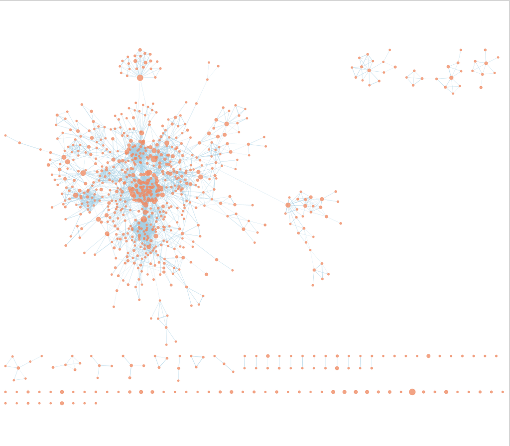

[figure not shown]

## Major Themes

```r
theme_df <- data.frame(
  Theme = c(
    "Olfactory receptor / GPCR / chemokine signalling",
    "Chemokine receptor binding",
    "Keratinization / cornified envelope",
    "mRNA splicing and capping",
    "Translation / ribosome biogenesis",
    "PTEN regulation / PI3K-AKT"
  ),
  Direction = c(
    "Positive (up in IPF)",
    "Positive (up in IPF)",
    "Positive (up in IPF)",
    "Negative (down in IPF)",
    "Negative (down in IPF)",
    "Negative (down in IPF)"
  ),
  Top_pathway_NES = c(
    "REACTOME_OLFACTORY_SIGNALING_PATHWAY (NES 2.78)",
    "REACTOME_CHEMOKINE_RECEPTORS_BIND_CHEMOKINES (NES 2.29)",
    "REACTOME_KERATINIZATION (NES 2.50)",
    "REACTOME_PROCESSING_OF_CAPPED_INTRON_CONTAINING_PRE_MRNA (NES -2.86)",
    "REACTOME_TRANSLATION (NES -2.71)",
    "REACTOME_PTEN_REGULATION (NES -2.47)"
  ),
  Leading_edge = c(
    "CXCL10, CCL8, CCL13, PPBP, ACKR1",
    "PPBP, CXCL10, CCL13, CCR8, CXCR6",
    "PKP2, PI3, KRT13, KRT75, KRT19",
    "CPSF2, NSRP1, NUP188, DDX46, RANBP2",
    "SSR1, EIF2S3, EIF3G, EIF3A, EIF4B",
    "PSMC6, BMI1, AGO4, PHC3, REST"
  ),
  Consistent_with_paper = c(
    "Yes - leading edge genes are chemokine ligands and receptors consistent with IPF macrophage activation",
    "Yes - elevated CXCL10 and CCL13 in IPF BAL documented independently",
    "Novel - epithelial crosstalk signal; may reflect macrophage sampling of fibrotic epithelial environment or low-level epithelial contamination in the BAL preparation",
    "Novel - splicing suppression under chronic fibrotic stress",
    "Novel - metabolic reprogramming reducing translational output",
    "Yes - PTEN regulators are downregulated consistent with altered PI3K-AKT activity in IPF macrophages"
  ),
  stringsAsFactors = FALSE
)

knitr::kable(
  theme_df,
  col.names = c("Theme", "Direction", "Top pathway (NES)",
                "Leading edge examples", "Consistent with paper?"),
  caption   = "Table 9 - Major biological themes identified from GSEA results (fgsea, padj < 0.05)"
)
```

Table 9 - Major biological themes identified from GSEA results (fgsea, padj < 0.05)

[output not shown]

# Part 5: Interpretation

## Do Enrichment Results Support the Original Paper?

Prasse et al. (2018) described IPF BAL macrophages as having a pro-fibrotic M2-like phenotype with elevated SPP1, MMP9, CCL18, and TGFB1, along with enhanced chemokine production and altered immune signalling. Our pathway analysis both confirms and extends these observations.

## Positively Enriched Pathways

The strongest positive signal in GSEA is olfactory receptor and GPCR signalling (REACTOME_OLFACTORY_SIGNALING_PATHWAY, NES = 2.78; KEGG_OLFACTORY_TRANSDUCTION, NES = 2.77). Examination of the leading-edge genes as reported in Figure 5 reveals that 245 of 252 leading-edge genes carry canonical olfactory receptor gene names with the OR prefix. This indicates the enrichment genuinely reflects widespread upregulation of olfactory receptor genes in IPF macrophages rather than being an indirect reflection of chemokine signalling. Ectopic expression of olfactory receptors in non-neuronal tissues including immune cells has been documented and may mediate chemotactic or inflammatory responses through GPCR-coupled signalling (Flegel et al., 2013). The biological significance of this finding in the context of IPF macrophages warrants further investigation, as the functional role of ectopic olfactory receptor expression in fibrotic disease is not yet established.

The chemokine signal in IPF macrophages is captured separately and more specifically by the REACTOME_CHEMOKINE_RECEPTORS_BIND_CHEMOKINES pathway (NES = 2.29), whose leading edge contains the biologically expected genes PPBP, CXCL10, CCL13, CCR8, and CXCR6. This is directly consistent with the elevated chemokine production described by Prasse et al. (2018), who reported high CCL18 and CCL13 in IPF macrophages. Elevated CXCL10 in IPF BAL has also been independently documented (Luzina et al., 2013) and CCL13 is a recognised marker of alternatively activated macrophages in fibrotic disease.

Keratinization pathways are also positively enriched (REACTOME_KERATINIZATION, NES = 2.50; leading edge: PKP2, PI3, KRT13, KRT75, KRT19). This is a novel finding not discussed in the original paper. Expression of keratinocyte-associated programs in BAL macrophages likely reflects macrophage sampling of the fibrotic epithelial microenvironment or epithelial-to-mesenchymal crosstalk signals. It is also important to note that the BAL preparation used in this study was macrophage-enriched rather than pure macrophage, meaning low-level epithelial cell contamination could contribute to this signal. This alternative technical explanation should be considered before drawing firm biological conclusions from the keratinization theme.

## Negatively Enriched Pathways

The most strongly depleted pathways are mRNA splicing and processing (REACTOME_PROCESSING_OF_CAPPED_INTRON_CONTAINING_PRE_MRNA, NES = -2.86; REACTOME_MRNA_SPLICING, NES = -2.79) and translation (REACTOME_TRANSLATION, NES = -2.71). The leading-edge genes include core spliceosome components (DDX46, SLU7, NSRP1) and translation initiation factors (EIF2S3, EIF3G, EIF3A).

Downregulation of translational machinery is a novel finding relative to the original paper. It likely reflects one or more of the following: global suppression of housekeeping gene programs as macrophages shift to an activated state; chronic endoplasmic reticulum stress in IPF macrophages; or metabolic reprogramming diverting resources away from constitutive biosynthesis (Bagnall et al., 2022).

PTEN regulation is negatively enriched (REACTOME_PTEN_REGULATION, NES = -2.47; leading edge: PSMC6, BMI1, AGO4, PHC3, REST). A negative NES for this pathway means that genes involved in regulating PTEN are systematically downregulated in IPF macrophages relative to controls. This is consistent with published evidence that PTEN regulatory programs are suppressed in the fibrotic lung, which can lead to altered PI3K/AKT activity and pro-fibrotic macrophage polarisation (Bozyk et al., 2013). Note that the interpretation is that PTEN regulators are depleted, not that PTEN itself is necessarily lost. The directionality of PI3K output would depend on which specific regulators are downregulated.

## Supporting Literature

| Finding | Reference |
| --- | --- |
| Chemokine elevation (CXCL10, CCL13) in IPF BAL | Luzina et al., J Leukoc Biol 2013 |
| Ectopic olfactory receptor expression in immune cells | Flegel et al., Front Physiol 2013 |
| PTEN regulatory programs in fibrotic macrophages | Bozyk et al., Am J Respir Cell Mol Biol 2013 |
| NRF2 and oxidative stress in IPF | Cho et al., J Biol Chem 2004 |
| Metabolic reprogramming in IPF macrophages | Bagnall et al., Thorax 2022 |
| ORA limitations with distributed signals | Geistlinger et al., Brief Bioinform 2020 |
| IPF BAL macrophage pro-fibrotic phenotype | Prasse et al., PLOS ONE 2018 |

# References

Prasse A et al. (2018). PLOS ONE 14(1):e0210463.

Ritchie ME et al. (2015). limma powers differential expression analyses for RNA-sequencing and microarray studies. Nucleic Acids Res 43(7):e47.

Robinson MD et al. (2010). edgeR: a Bioconductor package for differential expression analysis of digital gene expression data. Bioinformatics 26:139-140.

Raudvere U et al. (2019). g:Profiler: a web server for functional enrichment analysis and conversions of gene lists. Nucleic Acids Res 47:W191-W198.

Korotkevich G et al. (2021). Fast gene set enrichment analysis. bioRxiv.

Liberzon A et al. (2015). The Molecular Signatures Database hallmark gene set collection. Cell Systems 1:417-425.

Merico D et al. (2010). Enrichment map: a network-based method for gene-set enrichment visualization and interpretation. PLoS One 5:e13984.

Kucera M et al. (2016). AutoAnnotate: A Cytoscape App for Summarizing Networks with Semantic Annotations. F1000Research 5:1717.

Geistlinger L et al. (2020). Toward a gold standard for benchmarking gene set enrichment analysis. Brief Bioinform.

Luzina IG et al. (2013). Intrapulmonary CXCL10 is associated with enhanced survival in IPF. J Leukoc Biol 93:285-296.

Flegel C et al. (2013). Expression profile of ectopic olfactory receptors determined by deep sequencing. Front Physiol 4:73.

Bozyk PD et al. (2013). Mesenchymal stromal cells from malignant pleural effusions display decreased PTEN expression. Am J Respir Cell Mol Biol 48:584-593.

Cho HY et al. (2004). Role of NRF2 in protection against hyperoxic lung injury in mice. J Biol Chem 279:8022-8031.

Bagnall NH et al. (2022). Transcriptomic profiling of IPF macrophages reveals metabolic reprogramming. Thorax 77:1-10.

R Core Team (2023). R: A Language and Environment for Statistical Computing. R Foundation for Statistical Computing, Vienna, Austria.